# Perceived pitch of vibrato

Tamara Cook, B. Sc.

2019-09-23

# Thema: Worum geht es?

- Primer zum Themengebiet
- Musik: Vibrato
- Akustik

## Was ist Vibrato

- Musikalisches Stilmittel
- spezifische Charakteristik, mit der ein Klang versehen werden kann
- Verleiht dem Klang Fülle und Emotionalität

## Erzeugung: Praxisbeispiel

[video not shown]

## Physikalische Beschreibung

- periodische Frequenzmodulation
- Schwankung der Klangfrequenz über die Zeit hinweg zwischen unterer ($f_0$) und oberer ($f_1$) Frequenz
- Modulationsrate: Frequenz der Modulation, Abgrenzung von Trägerfrequenz
- Tiefe: $f_1/f_0$ (mus. Intervall)

## Exkurs: Cent-Skala

- Einheit für mus. Intervalle
- Verhältnisskaliert, besitzt einen Nullpunkt
- Auflösung: Ein Halbtonschritt = 100 Cent
- Eine Oktave umfasst 12 Schritte, also 1200 Cent
- JND liegt bei ca 5 Cent
- $c = \frac{1200}{\log{2}}\cdot\log{\frac{f_1}{f_0}}$

## Vibrato und Wahrnehmung

- beliebt bei Anfängern, kräftigerer Klang
- Viele Musiker glauben, man müsse hier weniger genau intonieren
- Bei ausreichender Rate wird Vibrato mit bestimmter Tonhöhe wahrgenommen (Genauigkeit ca 10 Cent)

# Das Experiment

## Fragestellung

- Hängt subjektive Tonhöhe von der Modulationsform ab?
- subj. Tonhöhe wird bei symmetrischer Modulation durch geometrisches Mittel einer Periode geschätzt
- $\overline{f} = \sqrt[n]{\prod_{i=1}^n f_i}$
- $f_0 < \overline{f} < f_1$
- Gehen bei Asymmetrie die langsameren Anteile stärker in Wahrnehmung ein?

## Hypothesen

- S.T. weicht von $\overline{f}$ ab in Richtung stabiler Anteile
- Abweichung hängt positiv mit Länge des stabilen Anteils zusammen

## Design

- Vibratotöne mit gleichem geometrischen Mittel darbieten
- UV: stabile Anteile in der Modulationsform (Länge und Ort)
- Länge: relativer Anteil $p$ einer Periode
- Ort: $f_0$ oder $f_1$
- AV: subjektive Tonhöhe

## Stimuli

- trapezförmige Modulationsformen ($\overline{f} = 500\mathrm{Hz}$)
- Tiefe: 150 Cent
- Jede Periode besteht aus zwei Flanken und einem mittleren Plateau
- Länge des Plateau bestimmt relativen stabilen Anteil $p$ (0, 0.25, 0.5 oder 0.75)
- Plateau entspricht $f_0$ oder $f_1$
- bei $p=0$ ist es dreieckig, kein Plateau
- insgesamt 7 Stimuli

## Trapezformen

[figure not shown]

## Apparatur

- Computer mit Kopfhörer und Tastatur
- OS X mit Octave
- Stimuli werden mit PsychPortAudio als frequenzmodulierte Sinustöne generiert
- Bildschirm nicht notwendig

## Aufgabe

- VP hört Stimulus auf einem Ohr und einen normalen Sinus auf dem anderen
- Per Tastatur wird die Tonhöhe des Sinus an den Stimulus angepasst
- kein Zeitdruck, Stimuli nacheinander abarbeiten
- einstellbare Schritte: 5, 100 und 1 Cent
- Lautstärke beider Töne ist anpassbar

## Ablauf

- Instruktion: Aufgabe und Tastaturbelegung
- Darbietung der 7 Stimuli, jeder viermal, Reihenfolge randomisiert
- Startfrequenz des Sinus randomisiert zwischen $250\mathrm{Hz}$ und $1\mathrm{kHz}$
- In jedem der 28 Trials nimmt die VP die Herstellung vor und geht mittels Enter zum nächsten Trial über
- Daten werden schließlich als CSV exportiert

## Ergebnis

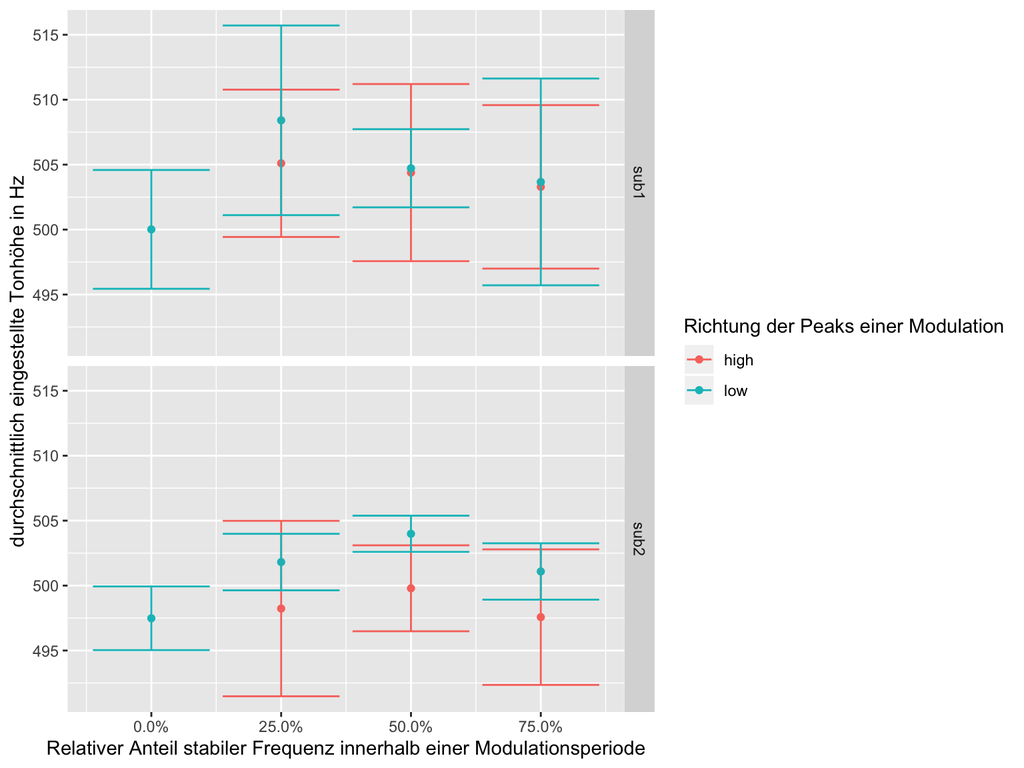

## Diskussion und Kritik

# Implementierung: Herausforderungen

## Bestimmung der Trapeze

- Wie findet man $f_0$ und $f_1$?
- Viele Parameter sind bekannt, aber die passenden Stützpunkte nicht
- Einzelner Freiheitsgrad durch vorgegebene Tiefe von 150 Cent
- Ist $f_0$ bekannt, so ist auch $f_1$ bekannt und umgekehrt

## Analytische Suche

- Mit Mathematica ließen sich Gleichungen zur Bestimmung von $f_0$ aus den Vorgaben ermitteln
- Mathematica arbeitet symbolisch, Matlab oder R hingegen numerisch
- Nicht für jedes Problem gibt es analytische Lösungen
- Zwei Seiten Integralrechnung später …

## Analytische Lösung

```matlab
function extremes_Hz = getExtremes(self)
  a = self.ratio();
  alpha = (a^(1/(1-1/a))) / exp(1);
  p = self.stable_rel;
  extremes_Hz = [ 0, 0 ];
  switch self.peak
  case "low"
    extremes_Hz(1) = self.pitch_Hz * a^(-p) * alpha^(p-1);
  case "high"
    extremes_Hz(1) = self.pitch_Hz * alpha^(p-1);
  end% switch
  extremes_Hz(2) = a*extremes_Hz(1);
end
```

## Fit

- Steht kein Mathematica zur Verfügung oder existiert keine analytische Lösung, kann man die Lösung auch fitten
- z.B. in Matlab der Simplex-Algorithmus via `fminsearch`
- versucht Prüfkriterium durch anpassen der Freiheitsgrade zu minimieren
- Prüfkriterium: eigene Funktion mit Freiheitsgraden als Eingabe und Prüfkriterium als Ausgabe
- wichtig: mit sinnvollen Startwerten anfangen

## Vibrato-Fit

```matlab
function err = errorfun(a, v)
  extremes_Hz = [ a, v.ratio() * a ];
  v = v.recalc(extremes_Hz);
  m = mean(v.modCycle_Hz, "g");
  err = (v.pitch_Hz - m)^2;
end
cd experiment;
v = Vibrato();
fprintf("Analytic f_0: %d\n", v.extremes_Hz(1));
[ a, err ] = fminsearch(@(a) errorfun(a, v), 300);
fprintf("Estimated f_0: %d\nerror: %d\n", a, err);
#> Analytic f_0: 489.133
#> Estimated f_0: 489.13
#> error: 1.20039e-05
```

## Beispiel: nichtlineare Regression

$$y = a\sqrt{x} + b$$

```matlab
function err = errorfun(params, data)
  a = params(1); b = params(2);
  y_hat = a*sqrt(data.x) + b;
  err = sum((data.y-y_hat).^2);
end
data.x = 1:50;
data.y = 5*sqrt(data.x) + 1;
[ params, err ] = fminsearch(@(params) errorfun(params, data), [ 1, 0 ]);
fprintf("a: %d\nb: %d\nError: %d", params(1), params(2), err);
#> a: 4.99997
#> b: 1.00012
#> Error: 1.61518e-07
```

## Phasensprünge

- Beim Aneinanderhängen von Sinustönen können hörbare Phasensprünge entstehen
- $a(f, t) = \sin{2πft}$
- Sinus transformiert die Phasen (Radianten) zu Amplituden (Werte pendeln zwischen -1 und 1)
- Alle $2\pi$ rad (Vollwinkel) ist der Sinus einmal vollständig gependelt
- die hörbaren Artefakte sind Unregelmäßigkeiten der Membran beim Pendeln

## Wiederholung eines Tons

- Der Folgeton muss mit der richtigen Phase beginnen, die an den vorigen Ton anschließt
- Soll ein Ton (endlos) repeatet werden, müssen Anfang und Ende zusammenpassen
- Man hört bereits, wenn die Startphase doppelt vorkommt (Anfang und Ende)

## Beispiel mit Fehler

```matlab
fs_Hz = 48000;
freq_Hz = 440;
duration_s = 1;
repeat_times = 10;
t_s = linspace(0, duration_s, duration_s*fs_Hz+1);
phase_rad = 2*pi*freq_Hz*t_s;
a = repmat(sin(phase_rad), 1, repeat_times);
audiowrite("soundsamples/sound1.wav", a, fs_Hz);
```

[interactive chart not shown]

## gleiches Beispiel korrekt

```matlab
fs_Hz = 48000;
freq_Hz = 440;
duration_s = 1;
repeat_times = 10;
t_s = linspace(0, duration_s, duration_s*fs_Hz+1);
phase_rad = t_s(1:end-1)*2*pi*freq_Hz;
a = repmat(sin(phase_rad), 1, repeat_times);
audiowrite("soundsamples/sound2.wav", a, fs_Hz);
```

[interactive chart not shown]

## Herstellungsmethode: dynamische Töne

- Werden Folgetöne dynamisch generiert, müssen die Startphasen mit „durchgeschleift“ werden
- Bei der Berechnung eines Tons wird gleichzeitig auch die nächste Startphase bestimmt, die dem nächsten Ton hinzugefügt wird
- möglicher Ansatz: Das letzte Element im Zeitvektor (Tondauer) führt zur neuen Startphase
- Nur der Modulo der Startphase von $2\pi$ ist entscheidend, so bleibt der Wert auch nach oben hin begrenzt

## Beispiel

```matlab
duration_s = 0.5; fs_Hz = 48000;
t_s = linspace(0, duration_s, duration_s*fs_Hz+1);
s = []; nextStartPhase = 0;
for f = [ 400, 600, 800 ]
  phase_rad = nextStartPhase + 2*pi*f*t_s;
  a = sin(phase_rad(1:end-1));
  nextStartPhase = mod(phase_rad(end), 2*pi);
  s = [ s, a ];
end
audiowrite("soundsamples/sound3.wav", s, fs_Hz);
```

[interactive chart not shown]

# Quellen

## Literatur

Mesz, B. A., & Eguia, M. C. (2009). The pitch of vibrato tones: A model based on instantaneous frequency decomposition. *Annals of the New York Academy of Sciences*, *1169*(1, III), 126—130. https://doi.org/10.1111/j.1749-6632.2009.04767.x